# Homework3

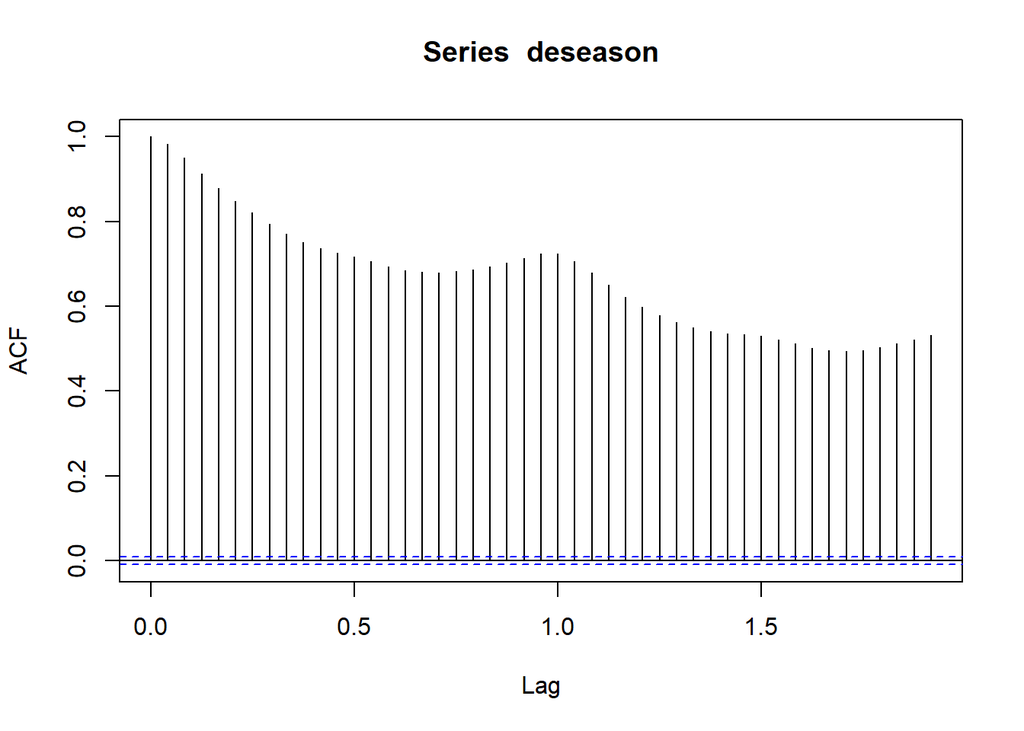

```r
acf(deseason)
```

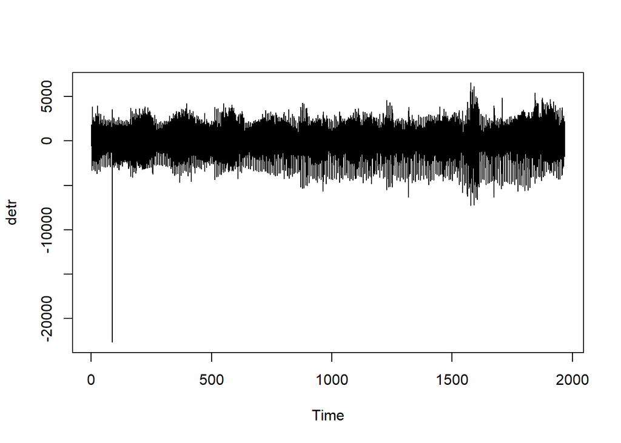

```r
detr<-deseason-ts_dec$trend
ts.plot(detr)
```

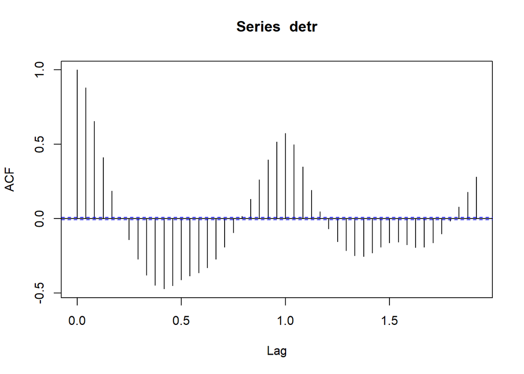

```r
acf(detr, na.action = na.pass)
```

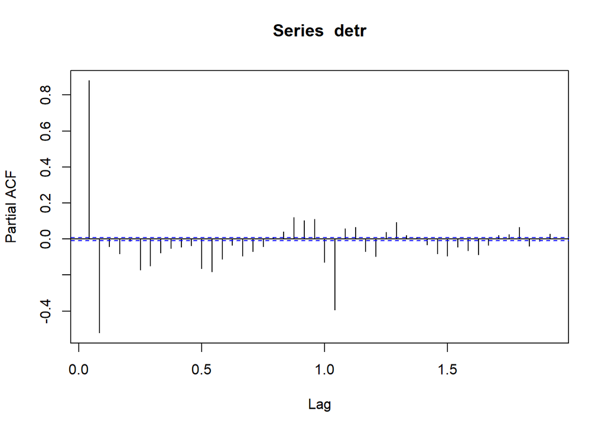

```r
pacf(detr,na.action = na.pass)
```

## Decomposing at Weekly Level

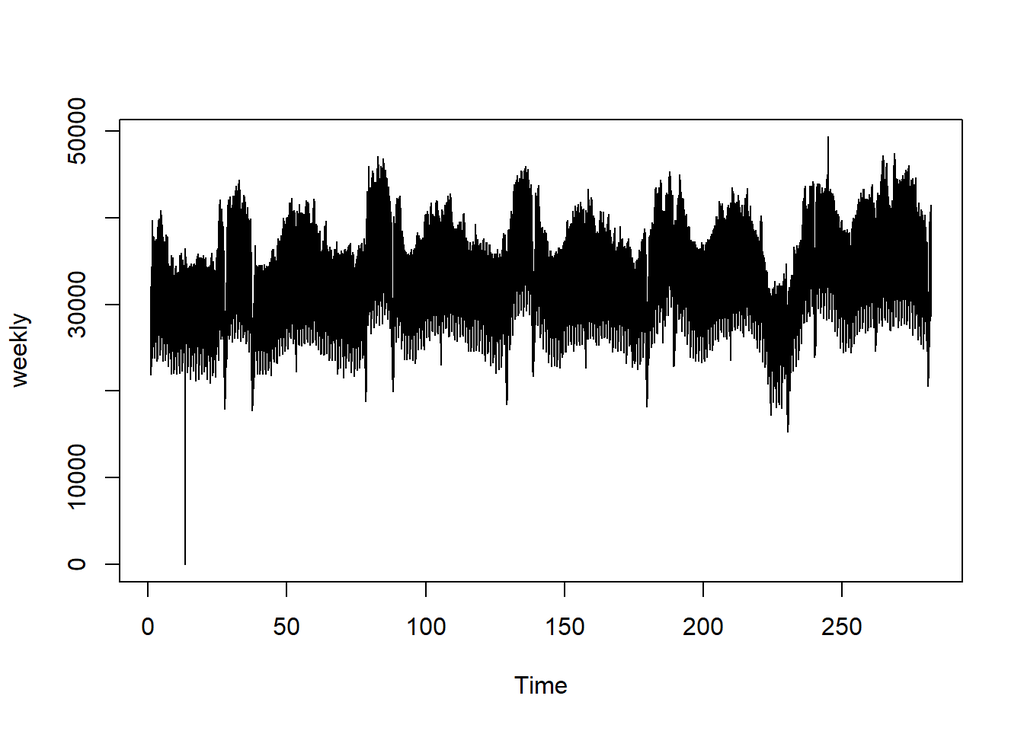

```r
weekly <- ts(hourly_consumption$Consumption,frequency = 24*7)
ts.plot(weekly)
```

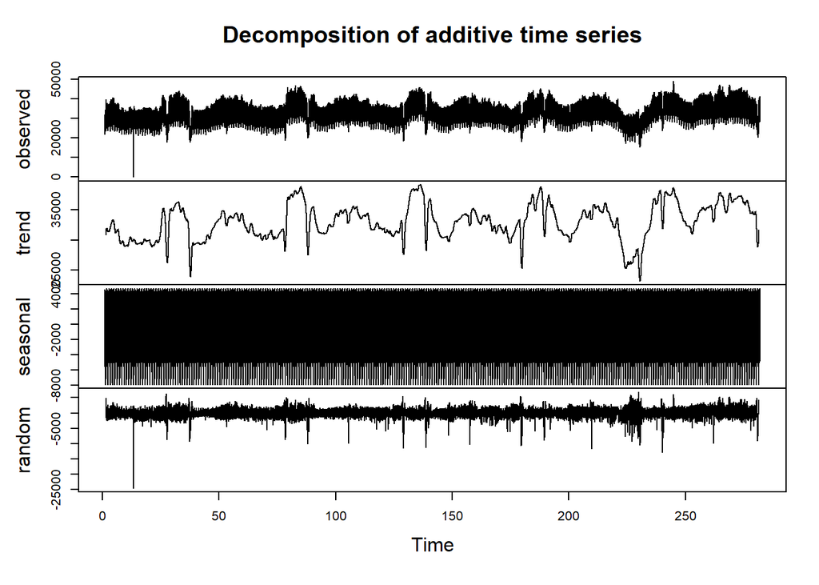

```r
weekly_dec <- decompose(x = weekly,type = "additive")
plot(weekly_dec)
```

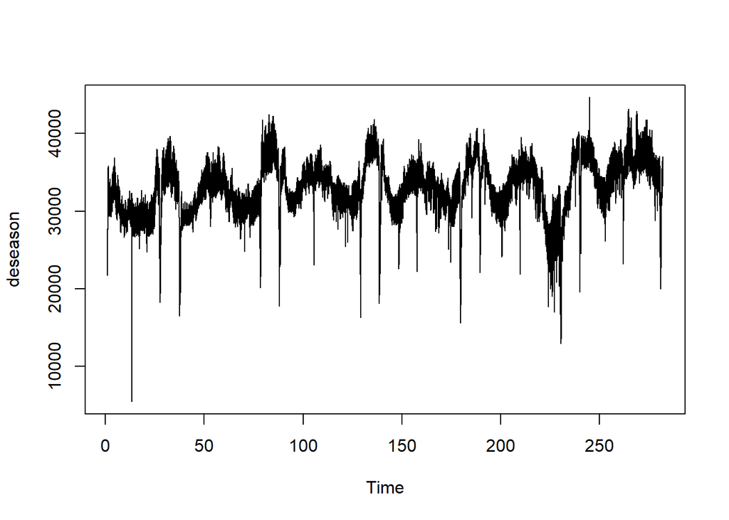

```r
deseason<-weekly-weekly_dec$seasonal
ts.plot(deseason)
```

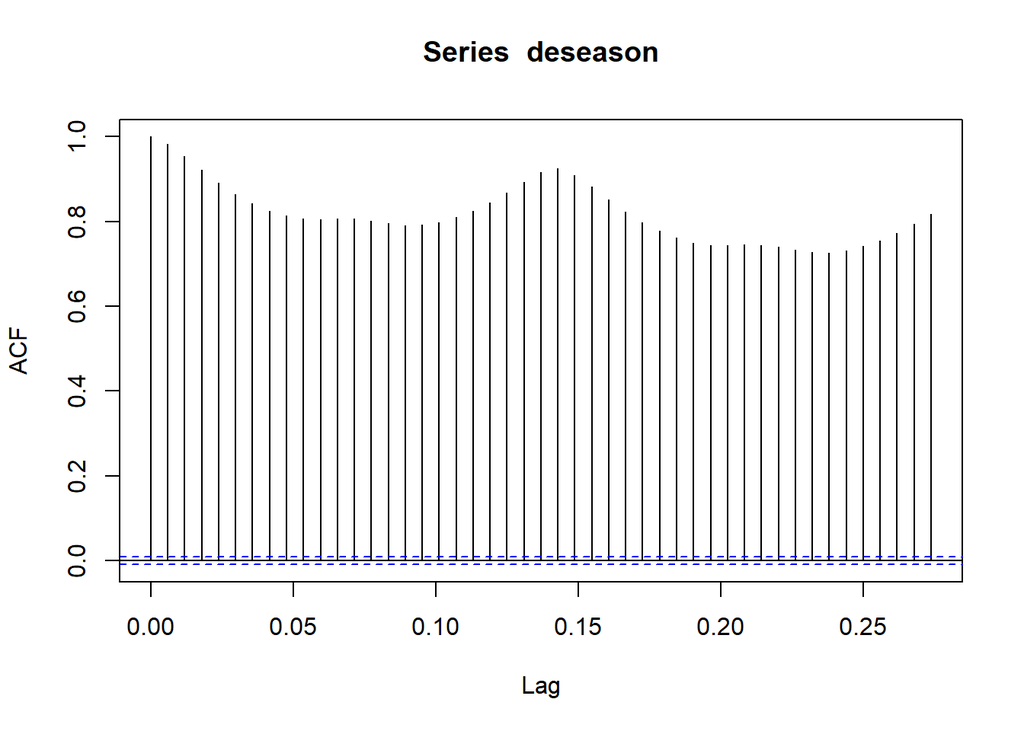

```r
acf(deseason)
```

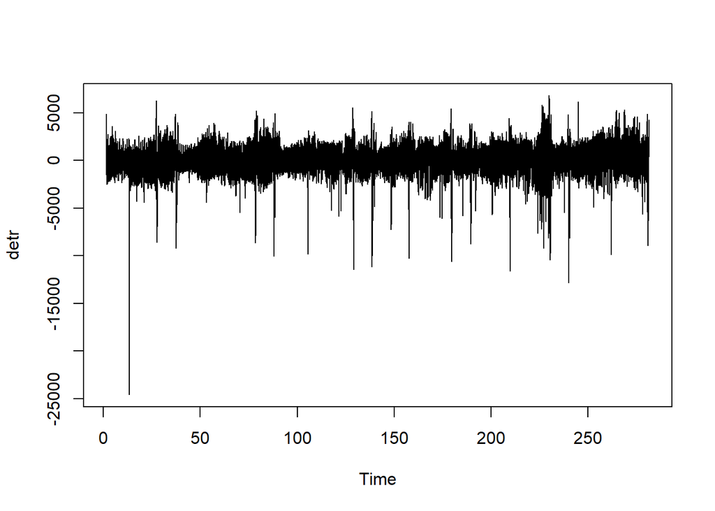

```r
detr<-deseason-weekly_dec$trend
ts.plot(detr)
```

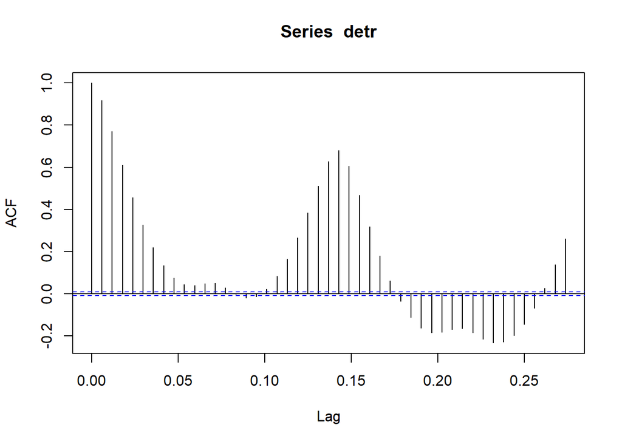

```r
acf(detr, na.action = na.pass)
```

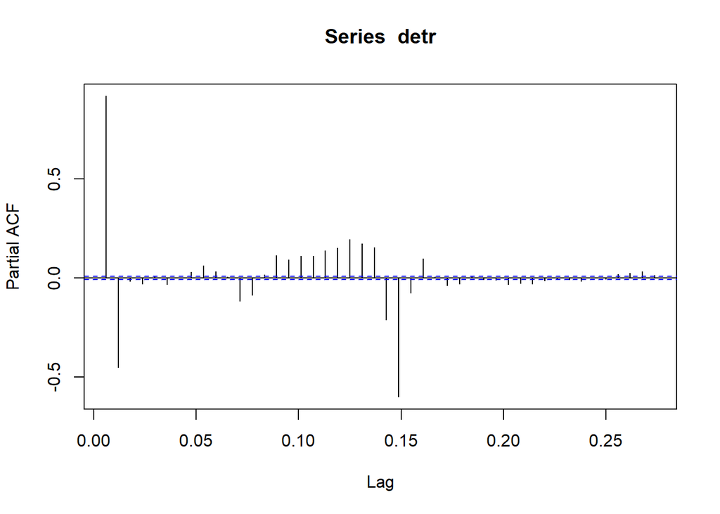

```r
pacf(detr,na.action = na.pass)
```

## AR Models

At this point, we can try to fit an AR model to the random component. We can use several lags and determine the best in terms of AIC.

```r
ar1 = arima(weekly_dec$random, order = c(1,0,0))
ar2 = arima(weekly_dec$random, order = c(2,0,0))
ar3 = arima(weekly_dec$random, order = c(3,0,0))
ar4 = arima(weekly_dec$random, order = c(4,0,0))
c(ar1=AIC(ar1), ar2=AIC(ar2), ar3=AIC(ar3), ar4=AIC(ar4))
```

```
##      ar1      ar2      ar3      ar4
## 733654.4 722906.0 722896.7 722855.1
```

ar4 gives the best result in terms of AIC.

## MA Models

We can also try to fit an MA model.

```r
ma1 = arima(weekly_dec$random, order = c(0,0,1))
ma2 = arima(weekly_dec$random, order = c(0,0,2))
ma3 = arima(weekly_dec$random, order = c(0,0,3))
ma4 = arima(weekly_dec$random, order = c(0,0,4))
ma5 = arima(weekly_dec$random, order = c(0,0,5))
c(ma1=AIC(ma1), ma2=AIC(ma2), ma3=AIC(ma3), ma4=AIC(ma4), ma5=AIC(ma5))
```

```
##      ma1      ma2      ma3      ma4      ma5
## 771819.8 747445.1 734563.0 728972.5 725530.1
```

ma5 gives the best result in terms of AIC.If we keep increasing q value,AIC value keeps decreasing but it would be time consuming and inefficient.

## ARMA Model and Prediction

Now our model is arma with p=4 and q=5.

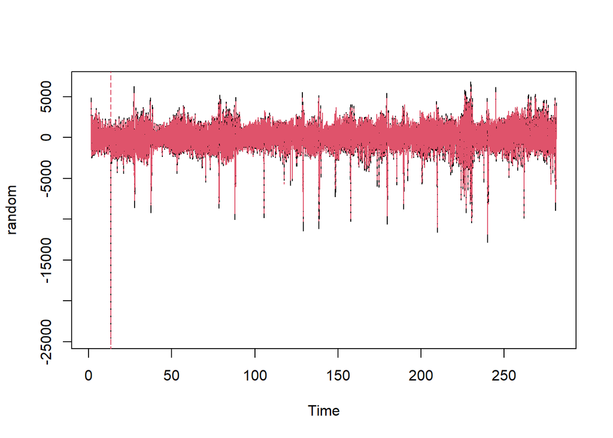

```r
model = arima(weekly_dec$random, order = c(4,0,5))
random <- weekly_dec$random
model_fitted <- random - residuals(model)
model_fitted_transformed <- model_fitted+weekly_dec$trend+weekly_dec$seasonal


plot(random)
points(model_fitted, type = "l", col = 2, lty = 2)
```

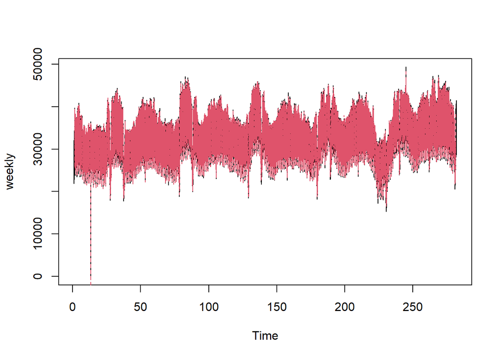

```r
plot(weekly)
points(model_fitted_transformed, type = "l", col = 2, lty = 2)
```

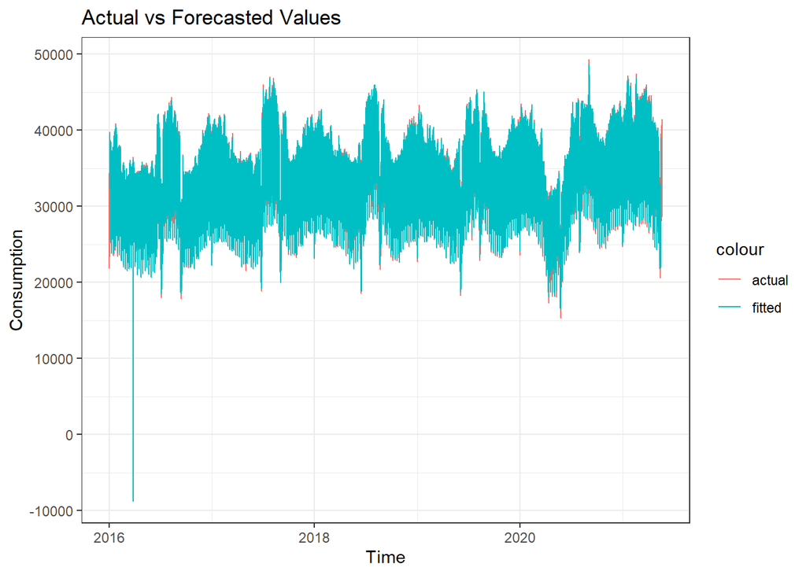

```r
ggplot(hourly_consumption, aes(x=Date)) +
  geom_line(aes(y=Consumption, col="actual")) +
  geom_line(aes(y=model_fitted_transformed, col="fitted")) +
    theme_bw() +
  labs(title="Actual vs Forecasted Values ",
       x="Time",
       y="Consumption")
```

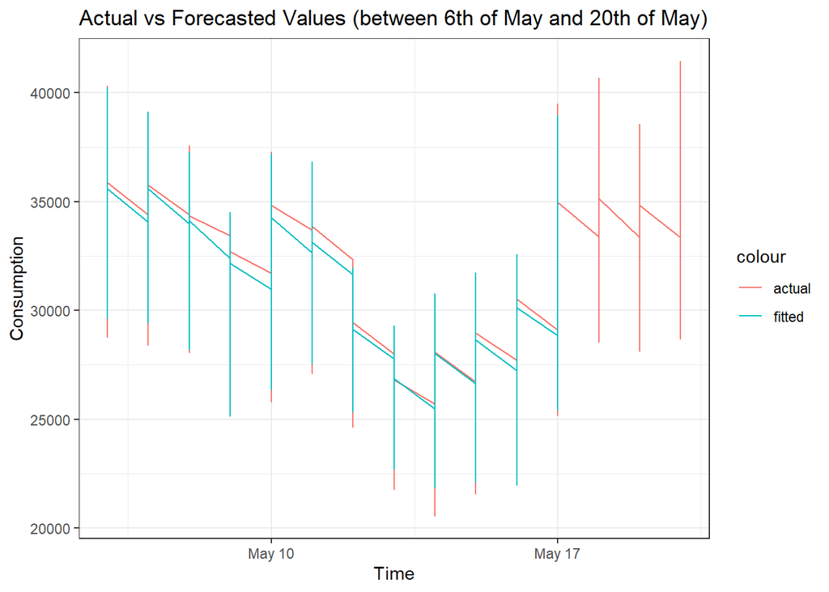

```r
hourly_consumption[,fitted:=model_fitted_transformed]
ggplot(hourly_consumption[Date<="2021-05-20" & Date>="2021-05-06"], aes(x=Date)) +
  geom_line(aes(y=Consumption, col="actual")) +
  geom_line(aes(y=fitted, col="fitted")) +
    theme_bw() +
  labs(title="Actual vs Forecasted Values (between 6th of May and 20th of May) ",
       x="Time",
       y="Consumption")
```

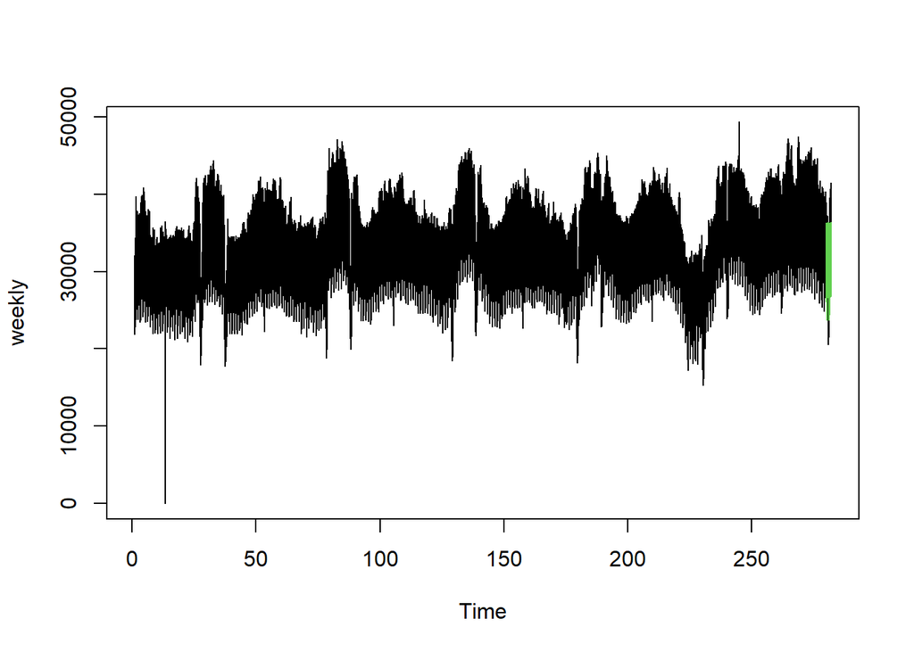

```r
model_forecast <- predict(model, n.ahead = 336)$pred
model_forecast=ts(model_forecast,frequency = 168,start=c(280,1))
seasonality=weekly_dec$seasonal[1:336]
last_trend_value <-tail(weekly_dec$trend[!is.na(weekly_dec$trend)],1)
model_forecast=model_forecast+last_trend_value+seasonality

plot(weekly)
points(model_forecast, type = "l", col = 3)
```

## Evaluation of Forecast Results

To evaluate the model, we can use daily MAPE, daily bias, and overall MAPE, bias and WMAPE.

```r
actual<-hourly_consumption$Consumption[46873:47208]
test <- data.frame(actual,model_forecast)
test<- data.table(test)
test
```

```
##        actual model_forecast
##   1: 34407.89       30704.67
##   2: 32984.77       29070.41
##   3: 32736.92       27963.02
##   4: 31913.44       27235.99
##   5: 31318.70       26930.66
##  ---
## 332: 37793.51       35863.38
## 333: 38805.79       35631.90
## 334: 38413.45       34939.92
## 335: 37630.77       34229.47
## 336: 36126.55       32727.42
```

```r
test[,error:=actual-model_forecast]
test[,bias:=error/actual]

test[,daily_bias:=sum(bias)/24,by=.(Date=hourly_consumption$Date[46873:47208])]
test[,mean:=mean(actual)]
test[,ape:=abs(error/actual)]
test[,daily_mape:=sum(ape)/24,by=.(Date=hourly_consumption$Date[46873:47208])]
test
```

```
##        actual model_forecast    error       bias daily_bias     mean        ape
##   1: 34407.89       30704.67 3703.222 0.10762712 0.07530634 31745.47 0.10762712
##   2: 32984.77       29070.41 3914.361 0.11867177 0.07530634 31745.47 0.11867177
##   3: 32736.92       27963.02 4773.900 0.14582617 0.07530634 31745.47 0.14582617
##   4: 31913.44       27235.99 4677.454 0.14656689 0.07530634 31745.47 0.14656689
##   5: 31318.70       26930.66 4388.037 0.14010918 0.07530634 31745.47 0.14010918
##  ---
## 332: 37793.51       35863.38 1930.128 0.05107035 0.09117020 31745.47 0.05107035
## 333: 38805.79       35631.90 3173.888 0.08178903 0.09117020 31745.47 0.08178903
## 334: 38413.45       34939.92 3473.531 0.09042486 0.09117020 31745.47 0.09042486
## 335: 37630.77       34229.47 3401.295 0.09038602 0.09117020 31745.47 0.09038602
## 336: 36126.55       32727.42 3399.128 0.09408948 0.09117020 31745.47 0.09408948
##      daily_mape
##   1: 0.07530634
##   2: 0.07530634
##   3: 0.07530634
##   4: 0.07530634
##   5: 0.07530634
##  ---
## 332: 0.09117020
## 333: 0.09117020
## 334: 0.09117020
## 335: 0.09117020
## 336: 0.09117020
```

Daily bias and daily MAPE are large on some days but in general, they are small enough.

## Conclusion

In conclusion, we did decomposing at different levels to understand characteristics of series. Then we tried to fit a model on random component of the decomposition at frequency of 168.The best ARMA model with lowest AIC value becomes ARMA(4,5). Finally, I evaluated the model according to daily bias and daily mean absolute percentage error.